# STAT 184 Final Project

Jiarui Fan

12/12

```r
# clean up R environment
rm (list = ls())
# load some packages
library(readr)
library(rvest)
library(xml2)
library(tidyverse)
library(DataComputing)
library(ggplot2)
library(tidyr)
library(lubridate)
```

## 1: Which is the Most Popular Ramen Product?

My guiding question & purpose of this analysis is to find out which is the most popular Ramen product. The reason I come up with such an idea is very simple. I am a huge Ramen fan, and I eat Ramen products several times a week. After consuming all these different types and flavors of Ramen products, I will rank them. For example, which has the best packaging, which has the best price, what brand has the most flavor, and so on. Therefore, I wonder what is the rank of Ramen product in other people’s opinion, and which is the most well-reviewed, highly rated, and best selling.

The biggest challenge that I encountered will be finding a supporting dataset. I misunderstood the instruction when I was doing the EDA, so I did two primary data sources instead of one primary and one supporting. It is kind of hard because this Ramen dataset is found in Kaggle, and it is already kind of well analyzed. Therefore, another supporting dataset is not easy to find. I didn’t find any suitable dataset from packages that have already loaded in this RStudio.I have searched for a more similar dataset like this Ramen data, but they are not suitable for supporting purposes. Then I tried to lower my standards, just look at one attribute. Finally, I found a dataset in Wikipedia that contains a list of Ramen Brands. I mainly used it as a tool for my data wangling later in the project.

### Data Access

#### Primary data

- [Ramen Ratings | Kaggle](https://www.kaggle.com/residentmario/ramen-ratings) This data set is found in Kaggle.
- The dataset owner is Aleksey Bilogur, he collected the data and maintained it. The last update is 3 years ago. However, Mr.Bilogur states that“This dataset is republished as-is from the original BIG LIST on https://www.theramenrater.com/.”
- According to the data description, the inspiration of the dataset owner is from these questions:
- What ingredients or flavors are most commonly advertised on ramen package labels?
- How do ramen ratings compare against ratings for other food products (like, say, wine)?
- How is ramen manufacturing internationally distributed?
- One case is a variety of Ramen with a certain brand, certain number of reviews, its style of packaging(Cup/Bowl/Tray), country, star rating(5-point scale), and if it went on Top 10.

##### Load data

```r
RamenFile<- file.choose()
```

```r
RamenData<-
  data.table::fread(RamenFile) %>%
  as.data.frame()
```

##### inspecting data

```r
str(RamenData)
```

```
'data.frame':   2580 obs. of  7 variables:
 $ Review #: int  2580 2579 2578 2577 2576 2575 2574 2573 2572 2571 ...
 $ Brand   : chr  "New Touch" "Just Way" "Nissin" "Wei Lih" ...
 $ Variety : chr  "T's Restaurant Tantanmen" "Noodles Spicy Hot Sesame Spicy Hot Sesame Guan-miao Noodles" "Cup Noodles Chicken Vegetable" "GGE Ramen Snack Tomato Flavor" ...
 $ Style   : chr  "Cup" "Pack" "Cup" "Pack" ...
 $ Country : chr  "Japan" "Taiwan" "USA" "Taiwan" ...
 $ Stars   : chr  "3.75" "1" "2.25" "2.75" ...
 $ Top Ten : chr  "" "" "" "" ...
```

```r
head(RamenData)
```

|  | Review # | Brand | Variety | Style | Country | Stars | Top Ten |
| --- | --- | --- | --- | --- | --- | --- | --- |
| 1 | 2580 | New Touch | T's Restaurant Tantanmen | Cup | Japan | 3.75 |  |
| 2 | 2579 | Just Way | Noodles Spicy Hot Sesame Spicy Hot Sesame Guan-miao Noodles | Pack | Taiwan | 1 |  |
| 3 | 2578 | Nissin | Cup Noodles Chicken Vegetable | Cup | USA | 2.25 |  |
| 4 | 2577 | Wei Lih | GGE Ramen Snack Tomato Flavor | Pack | Taiwan | 2.75 |  |
| 5 | 2576 | Ching's Secret | Singapore Curry | Pack | India | 3.75 |  |
| 6 | 2575 | Samyang Foods | Kimchi song Song Ramen | Pack | South Korea | 4.75 |  |

#### Supporting data

- [List of instant noodle brands - Wikipedia](https://en.wikipedia.org/wiki/List_of_instant_noodle_brands) This data set is found in Wikipedia.
- The dataset owner is Wikipedia. This page was last edited on 10 December 2020, at 17:19 (UTC).
- One case is a brand of a Ramen noodle prodoct with its current owner and a picture, also with a text description.

##### load data

```r
web_page <- "https://en.wikipedia.org/wiki/List_of_instant_noodle_brands"
SetOfTables <- web_page %>%
  read_html() %>%
  html_nodes(css = "table") %>%
  html_table(fill = TRUE)
length(SetOfTables)
```

```
[1] 5
```

```r
TableOfBrands <- SetOfTables[[1]]
```

##### inspecting data

```r
glimpse(TableOfBrands)
```

```
Observations: 62
Variables: 4
$ Name         <chr> "ABC", "Acecook", "Aïki noodles", "Alhami", "Ansungtangmyun", "Buitoni Instant Noodl…
$ Picture      <lgl> NA, NA, NA, NA, NA, NA, NA, NA, NA, NA, NA, NA, NA, NA, NA, NA, NA, NA, NA, NA, NA, …
$ Currentowner <chr> "ABC President", "Acecook", "Continental foods", "Olagafood", "Nongshim", "Buitoni",…
$ Description  <chr> "Brand in Indonesia.", "Largest instant noodle brand in Vietnam[2]", "Popular instan…
```

```r
tail(TableOfBrands)
```

|  | Name | Picture | Currentowner | Description |
| --- | --- | --- | --- | --- |
| 57 | Top Ramen | NA | Nissin Foods | Sold in the United States starting in 1972, in Nissin's first foray overseas.[12] |
| 58 | Vifon | NA | Vietnam Food Industries Joint Stock Company | Large instant noodle brand in Vietnam, speciality product are instant rice noodles and instant pho[2][38] |
| 59 | Vite Ramen | NA | Vite Ramen | Vite Ramen is an instant noodle company from the United States that makes nutritionally-complete instant ramen. |
| 60 | Wai Wai | NA | Chaudhary Group | Manufactured in Thailand since 1972[39] and in Nepal since 1984. |
| 61 | Yatekomo | NA | Gallina Blanca (under license of Ajinomoto Group) | Manufactured and sold in Spain starting in 2014. |
| 62 | Yum Yum | NA | Wan Thai Foods Industry/Ajinomoto Thailand | One of the first instant noodles brand in Thailand,[40] Manufactured since 1971.[41] Yum Yum is sold in Southeast Asian, European and overseas countries. |

### Data Wrangling

#### General

```r
#general data wrangling, select the attributs will be used in later steps
RamenData <-
  RamenData%>%
  na.omit(RamenData)%>%  # this removed rows that conatins NA
  mutate(Stars = as.numeric(Stars), `Review #` = as.numeric(`Review #`))%>%
  select(`Review #`, Brand, Variety, Style, Country, Stars)
```

```r
#general data wrangling, select the attributs will be used in later steps
TableOfBrands<-
  TableOfBrands%>%
  select(Name, Currentowner)
```

#### join

Here I joined roman data and the brand data to form a new data table called BigBrands.

```r
BigBrands<-
  RamenData%>%
  inner_join(TableOfBrands, by = c("Brand" = "Name"))
str(BigBrands)
```

```
'data.frame':   392 obs. of  7 variables:
 $ Review #    : num  2576 2574 2556 2542 2529 ...
 $ Brand       : chr  "Ching's Secret" "Acecook" "Ching's Secret" "Acecook" ...
 $ Variety     : chr  "Singapore Curry" "Spice Deli Tantan Men With Cilantro" "Hot Garlic Instant Noodles" "Super Cup Yochan Ika Yakisoba" ...
 $ Style       : chr  "Pack" "Cup" "Pack" "Tray" ...
 $ Country     : chr  "India" "Japan" "India" "Japan" ...
 $ Stars       : num  3.75 4 4.25 1.5 4.5 3.5 4 3.5 1.5 4.25 ...
 $ Currentowner: chr  "Capital Foods" "Acecook" "Capital Foods" "Acecook" ...
```

Here I filtered out star ratings that are below 4.5

```r
ByStars<-
  BigBrands%>%
  select(Brand, Stars, Variety, Country,Style)%>%
  group_by(Brand)%>%
  filter(Stars>=4.5)%>%
  arrange(desc(Stars))
nrow(ByStars)
```

```
[1] 74
```

Here I filtered out review numbers that are below 1000

```r
ByReview<-
  BigBrands%>%
  filter(`Review #`>=1000)%>%
  select(Variety, Country,Style,`Review #`)
nrow(ByReview)
```

```
[1] 190
```

By join ByStars and ByReview, I get a data set that contains the Ramen product that is highly rated and reviewed

```r
Reviews_Satrs<-
  ByStars%>%
  full_join(ByReview, by= "Variety")
head(Reviews_Satrs)
```

| Brand | Stars | Variety | Country.x | Style.x | Country.y | Style.y | Review # |
| --- | --- | --- | --- | --- | --- | --- | --- |
| Vifon | 5 | Viet Cuisine Bun Rieu Cua Sour Crab Soup Instant Rice Vermicelli | Vietnam | Bowl | Vietnam | Bowl | 2354 |
| Maggi | 5 | 2 Minute Noodles Masala Spicy | India | Pack | India | Pack | 2304 |
| MAMA | 5 | Oriental Kitchen Instant Rice Vermicelli In Gravy | Thailand | Pack | Thailand | Pack | 2179 |
| MAMA | 5 | Instant Rice Vermicelli Yentafo Tom Yam Mohfai | Thailand | Pack | Thailand | Pack | 2176 |
| MAMA | 5 | Cup Rice Noodles Tom Saab Flavour | Thailand | Cup | Thailand | Cup | 2174 |
| Maruchan | 5 | Instant Lunch Chipotle Chicken Flavor Ramen Noodle Soup | USA | Cup | USA | Cup | 2132 |

Since the current Review_Stars have multiple Country and Style variables, we will make this table cleaner.

#### spread or gather operation

```r
Reviews_Satrs <-
Reviews_Satrs%>%
  gather(key = from, value =Style, Style.x, Style.y,na.rm = TRUE)%>%
  gather(key = from1, value =Country, Country.x, Country.y,na.rm = TRUE)%>%
  na.omit(Reviews_Satrs)
head(Reviews_Satrs)
```

| Brand | Stars | Variety | Review # | from | Style | from1 | Country |
| --- | --- | --- | --- | --- | --- | --- | --- |
| Vifon | 5 | Viet Cuisine Bun Rieu Cua Sour Crab Soup Instant Rice Vermicelli | 2354 | Style.x | Bowl | Country.x | Vietnam |
| Maggi | 5 | 2 Minute Noodles Masala Spicy | 2304 | Style.x | Pack | Country.x | India |
| MAMA | 5 | Oriental Kitchen Instant Rice Vermicelli In Gravy | 2179 | Style.x | Pack | Country.x | Thailand |
| MAMA | 5 | Instant Rice Vermicelli Yentafo Tom Yam Mohfai | 2176 | Style.x | Pack | Country.x | Thailand |
| MAMA | 5 | Cup Rice Noodles Tom Saab Flavour | 2174 | Style.x | Cup | Country.x | Thailand |
| Maruchan | 5 | Instant Lunch Chipotle Chicken Flavor Ramen Noodle Soup | 2132 | Style.x | Cup | Country.x | USA |

#### reduction and/or transformation functions

The code below counts the number for each brands

```r
brandcount <-
  RamenData%>%
  group_by(Brand)%>%
  summarise(count=n())
```

Then I created allStars for the total Star rating for each brand, and then I joined the brand and allStars

```r
StarsBrand <-
  RamenData%>%
  group_by(Brand)%>%
  summarise(allStars = sum(Stars))
StarsBrand <-
  brandcount%>%
  full_join(StarsBrand, by = "Brand")
```

Finally, this Stars shows the mean Star rating for each brand

#### Function

```r
getMean <- function(total,count){
  total/count
}
```

```r
StarsBrand <-
  StarsBrand%>%
  mutate(meanStar = getMean(allStars,count))%>%
  select(Brand,count, meanStar)%>%
  arrange(desc(meanStar))
head(StarsBrand)
```

| Brand | count | meanStar |
| --- | --- | --- |
| ChoripDong | 1 | 5 |
| Daddy | 1 | 5 |
| Daifuku | 1 | 5 |
| Foodmon | 2 | 5 |
| Higashi | 1 | 5 |
| Jackpot Teriyaki | 1 | 5 |

```r
meanStarsBrand <-
  StarsBrand%>%
  left_join(Reviews_Satrs, by = "Brand")
meanStarsBrand <- na.omit(meanStarsBrand)
```

This code below is to find of the most popular style of Ramen product

```r
StyleReviewed <-
  ByReview%>%
  group_by(Style)%>%
  summarise(count=sum(`Review #`))%>%
  arrange(desc(count))
StyleReviewed
```

| Style | count |
| --- | --- |
| Pack | 181880 |
| Cup | 73801 |
| Bowl | 67666 |
| Tray | 7894 |

### Data Visualization

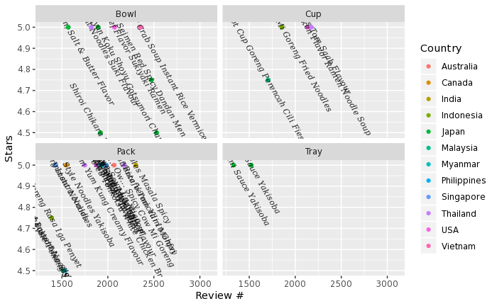

```r
plot1 <-
  Reviews_Satrs%>%
    filter(Style != "NA")%>%
    ggplot(aes(x=`Review #`, y = Stars, label = Variety))+geom_point(aes(color=Country))+facet_wrap(~Style)+geom_text(family="Times", fontface="italic", lineheight=.8, size = 3, angle = -60, alpha=0.3) + xlim(1300, 3100)
plot1
```

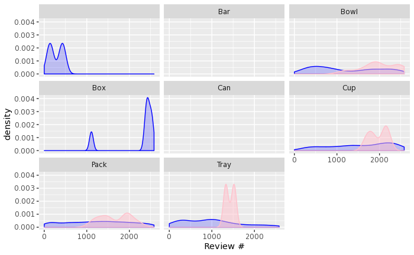

```r
plot2 <-
  RamenData%>%
  ggplot(aes(x=`Review #`))+geom_density(fill = "blue", color = "blue", alpha = 0.2)  + geom_density(data = meanStarsBrand, aes(x=`Review #`), fill= "pink",color="pink", alpha = 0.5) +facet_wrap(~Style)
plot2
```

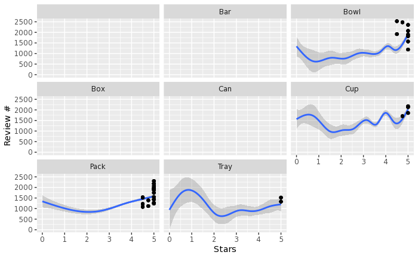

```r
plot3 <-
RamenData %>%
  ggplot(aes(x = Stars, y = `Review #`)) + geom_smooth() + geom_point(data = meanStarsBrand, aes(x = Stars, y = `Review #`))+facet_wrap(~Style)
plot3
```

### Conclusion

To have a closer look at the finall winner with the highest ranking and most reviews. Also, From StyleReviewed, we know that the most popular package is pack.

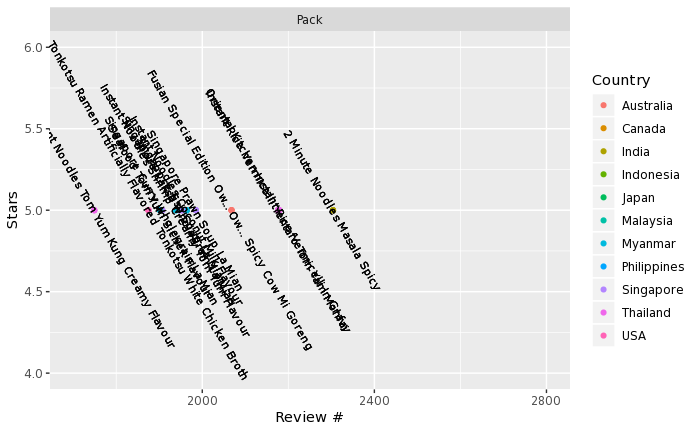

```r
plot4 <-
  Reviews_Satrs%>%
    filter(Style == "Pack")%>%
    ggplot(aes(x=`Review #`, y = Stars, label = Variety))+geom_point(aes(color=Country))+facet_wrap(~Style)+geom_text(size = 3, angle = -60, alpha=0.8) + xlim(1700, 2800) + ylim(4, 6)
plot4
```

The winner is – 2 Minute Noodles Masala Spicy from India!!